# Introduction to R programming for data science Day 3 exercises

Dr. Francesca Finotello

Medical University of Innsbruck, Austria

# Data structures: matrices, data.frames, and lists

## Ex. 3.1

Initialize a matrix with 2 rows and 3 columns that has all 1’s on the first row and all 2’s on the second row.

```r
matrix <- matrix( c(1,1,1,2,2,2),
                  nrow = 2,
                  ncol = 3,
                  byrow = TRUE)
```

Give it column and row names as you wish.

```r
rownames(matrix) <- paste("Gene", seq(1,nrow(matrix)), sep="_")
colnames(matrix) <- paste("Sample", seq(1,ncol(matrix)), sep="_")
matrix
```

```
##        Sample_1 Sample_2 Sample_3
## Gene_1        1        1        1
## Gene_2        2        2        2
```

Check its dimensions.

```r
dim(matrix)
```

```
## [1] 2 3
```

```r
nrow(matrix)
```

```
## [1] 2
```

```r
ncol(matrix)
```

```
## [1] 3
```

## Ex. 3.2

Initialize a numeric vector to store the year in which you got your driving license and first car, respectively (NA values are possible).

```r
driver <- c(2019, NA)
```

Set appropriate names.

```r
names(driver) <- c("license", "car")
```

Initialize a character vector to store the names of your favorite cities in Europe (as many as you like).

```r
favcities <- c("Venice", "Innsbruck", "Rome")
```

Save both vectors in a list using meaningful names.

```r
myInfo <- list(car = driver, cities = favcities)
myInfo
```

```
## $car
## license     car
##    2019      NA
##
## $cities
## [1] "Venice"    "Innsbruck" "Rome"
```

Extract the information about the your favorite cities using a numeric index and the list names.

```r
myInfo[[2]]
```

```
## [1] "Venice"    "Innsbruck" "Rome"
```

```r
myInfo[["cities"]]
```

```
## [1] "Venice"    "Innsbruck" "Rome"
```

## Ex. 3.3

Imagine you have an experiment with 4 lung cancer cell lines: 2 from adenocarcinomas (LUAD) and 2 from squamous cell carcinomas (LUSC).

One cell line from each cancer subtype is treated with a drug, the other one is untreated, as shown in the figure below.

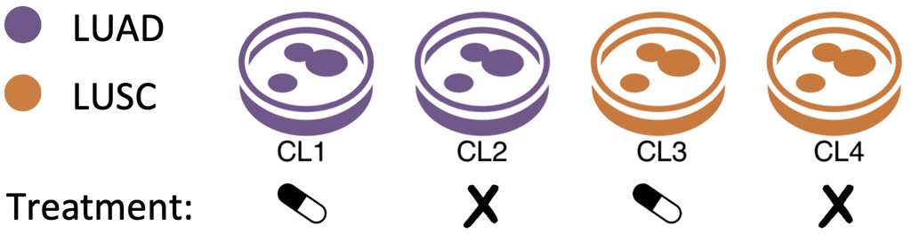

Save in a data.frame the info about the experiment: cell line identifier, lung-cancer sub-type, and treatment.

```r
experiment <- data.frame(id = paste("CL", seq(1,4), sep=""),
                         cancer = rep(c("LUAD", "LUSC"), each=2),
                         treatment = rep(c("drug", "control"), times=2))
experiment
```

```
##    id cancer treatment
## 1 CL1   LUAD      drug
## 2 CL2   LUAD   control
## 3 CL3   LUSC      drug
## 4 CL4   LUSC   control
```

Check how many rows and columns the data.frame has.

```r
dim(experiment)
```

```
## [1] 4 3
```

```r
nrow(experiment)
```

```
## [1] 4
```

```r
ncol(experiment)
```

```
## [1] 3
```

## Ex. 3.4

Initialize then following matrix in R:

```r
M <- matrix(1:6, nrow=3, byrow=FALSE)
colnames(M) <- c("Sample.A", "Sample.B")
rownames(M) <- c("Gene.1", "Gene.2", "Gene.3")
```

Save the second row of the *M* matrix into:

- A vector called *v*
- A 1x2 matrix called *N*

Try to use both:

- A numeric index

```r
v <- M[2,]
v
```

```
## Sample.A Sample.B
##        2        5
```

```r
N <- M[2,,drop=FALSE]
N
```

```
##        Sample.A Sample.B
## Gene.2        2        5
```

- The matrix row names

```r
v <- M["Gene.2",]
v
```

```
## Sample.A Sample.B
##        2        5
```

```r
N <- M["Gene.2",,drop=FALSE]
N
```

```
##        Sample.A Sample.B
## Gene.2        2        5
```

Assess the length of *v* and the number of columns of *N*.

```r
length(v)
```

```
## [1] 2
```

```r
ncol(N)
```

```
## [1] 2
```

## Ex. 3.5

Initialize a 10x5 matrix named *M1* composed of all 1’s.

```r
M1 <- matrix(1, nrow=10, ncol=5)
```

Initialize a 5x6 matrix named *M2* composed of all 2’s.

```r
M2 <- matrix(2, nrow=5, ncol=6)
```

Transpose *M2* using the **t** function.

```r
M2 <- t(M2)
```

Create a matrix named *M3* by concatenating *M1* and *M2* rows.

```r
M3 <- rbind(M1,M2)
```

Use the **head** function to extract the first 10 rows of *M3* corresponding to *M1*.

```r
head(M3, nrow(M1))
```

```
##       [,1] [,2] [,3] [,4] [,5]
##  [1,]    1    1    1    1    1
##  [2,]    1    1    1    1    1
##  [3,]    1    1    1    1    1
##  [4,]    1    1    1    1    1
##  [5,]    1    1    1    1    1
##  [6,]    1    1    1    1    1
##  [7,]    1    1    1    1    1
##  [8,]    1    1    1    1    1
##  [9,]    1    1    1    1    1
## [10,]    1    1    1    1    1
```

Similarly, use the **tail** function to extract the rows of *M3* corresponding to *M2*.

```r
tail(M3, nrow(M2))
```

```
##       [,1] [,2] [,3] [,4] [,5]
## [11,]    2    2    2    2    2
## [12,]    2    2    2    2    2
## [13,]    2    2    2    2    2
## [14,]    2    2    2    2    2
## [15,]    2    2    2    2    2
## [16,]    2    2    2    2    2
```

Count the occurrences of 1’s and 2’s in M3.

```r
table(M3)
```

```
## M3
##  1  2
## 50 30
```

## Ex. 3.6

Create a vector *a* containing the first 100 positive integers.

```r
a <- seq(1,100)
```

Create a vector *b* containing the first 200 even numbers.

**Tip**: to consider only even numbers, type `help(seq)` to learn how to use its *by* and *length.out* parameters.

```r
b <-  seq(2, by=2, length.out=200)
```

Verify that all elements in *b* are multiple of 2 and that its length is 200.

**Tip**: the **all** function can be used to check that all the elements of a vector satisfy a condition.

```r
all((b %% 2) == 0 )
```

```
## [1] TRUE
```

```r
length(b)
```

```
## [1] 200
```

Initialize a vector *c* with the square root of *b*.

```r
c <- sqrt(b)
```

Save *a*, *b*, and *c* in a list and compute their mean and standard deviations using the **lapply** function.

```r
abc <- list(a,b,c)
lapply(abc, mean)
```

```
## [[1]]
## [1] 50.5
##
## [[2]]
## [1] 201
##
## [[3]]
## [1] 13.38188
```

```r
lapply(abc, sd)
```

```
## [[1]]
## [1] 29.01149
##
## [[2]]
## [1] 115.7584
##
## [[3]]
## [1] 4.694183
```

# Functions

## Ex. 3.7

Write a function that takes as argument a numeric vector, computes its mean, variance, minimum, and maximum, and prints to screen the results together with some explanatory messages (e.g. “The mean of the vector is:…\n”) using the **cat** function.

**Tip**: the special character “\n” can be used at the end of the messages to go to a new line.

```r
vectorstats <- function (myvec) {

  v.mean <- mean(myvec)
  v.var <- var(myvec)
  v.min <- min(myvec)
  v.max <- max(myvec)

  cat("The mean of the vector is:", v.mean, "\n")
  cat("The variance of the vector is:", v.var, "\n")
  cat("The minimum of the vector is:", v.min, "\n")
  cat("The maximum of the vector is:", v.max, "\n")

}
```

Apply your function to the *a* vector of Ex. 3.6.

```r
vectorstats(a)
```

```
## The mean of the vector is: 50.5
## The variance of the vector is: 841.6667
## The minimum of the vector is: 1
## The maximum of the vector is: 100
```

## Ex. 3.8

Write a function that takes as arguments a numeric matrix and a parameter called *dim* that can have a value of either 1 or 2.

The function should compute the median of of the input matrix by rows, when *dim* equals 1, or by columns, when *dim* equals 2, using the **apply** function.

It then rounds the median to two decimal digits and return the results in a form of a numeric vector.

```r
getmedian <- function (mymatrix, dim) {

  res <- apply(mymatrix, dim, median)
  res.round <- round(res, digits = 2)
  return(res.round)

}
```

Apply this function to the *M3* matrix of Ex. 3.5 specifying once *dim = 1* and once *dim = 2*.

```r
getmedian(M3, dim=1)
```

```
##  [1] 1 1 1 1 1 1 1 1 1 1 2 2 2 2 2 2
```

```r
getmedian(M3, dim=2)
```

```
## [1] 1 1 1 1 1
```